# Tarea 03

Curso IE0217 Estructuras abstractas y algoritmos para ingeniería - UCR II-2022 20/10/2022

Profesor Freddy Rojas Ch.

# Enunciado

En esta tarea deben hacer una *rama* en el espacio del GIT server de cada estudiante con el nombre *Tarea03*.

Dentro de esta carpeta incluirán un archivo *py* por cada parte de la tarea.

En *Vistual Studio Code* hacen el trabajo dentro de la carpeta del área GIT de las tareas de manera que estén sincronizados con GIT y con **VSC**

Resolver en Python 3 los siguientes requerimientos:

#### 1. Calculos.py

Dado lista1= [13,2,104,36,9,120,29,500,89,41,65,7 ] y diccionario={0:20,1:320,2:90,3:147,4:122,5:717,6:2,7:77,8:112,9:14,10:17,11:24}

1. Construya una función en Python que recibe como primer parámetro la lista y segundo el diccionario y genera una lista de salida que contiene los datos de la lista y los valores del diccionario ordenados de menor a mayor.
2. Usando las bibliotecas vistas en clase calcular para la lista y para los valores del diccionario: la media, la desviación estándard y la mediana (investigar como se calcula)
3. Haga una copia de la lista y una copia del diccionario y hacer una función en Python que tome los llaves del diccionario y los valores en la lista y devuelver un diccionario.

#### 2. Tablas.py

1. Construir una tabla con *pandas* a partir del siguiente diccionario. La construcción debe contener un índice de tipo string, provisto por el estudiante. ej. “est1”, “est2”, …

```python
import pandas as pd
from numpy import mean, std
datos = {'nombre': ["Marco","Francisco","Roberto","Mariel","Sonia","John","Charles"],
         'carrera': ["Ing. Eléctrica","Educacion Física","Matemáticas","Ing. Mecánica","Derecho","Idiiomas","Ing. Civil"],
         'Edad': [21,20,19,29,22,21,22]
         }
```

#### 3 ExploracionCovid.py

En el ejercico a tomado un archivo con los datos provenientes del sitio oficial:

*COVID-19 Data Repository by the Center for Systems Science and Engineering (CSSE) at Johns Hopkins University*

en el URL= *https://github.com/CSSEGISandData/COVID-19*

El archivo que se entrega junto con enunciado de la tarea ha sido procesado y reacomodado. Este corresponde a los efectivos por día para una serie de países y tiene en las observaciones una serie de fechas.

El nombre del archivo es: *time_series_covid19_confirmed_ready.csv*

Su vista previa es la siguiente:

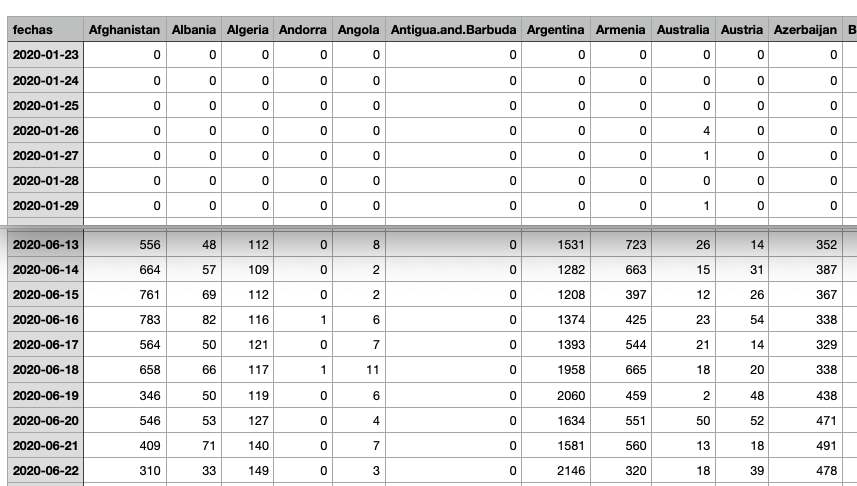

Vista ajustada casos confirmados de Covid-19

```
##        fechas Afghanistan Albania Algeria Andorra Angola Antigua.and.Barbuda
## 1  2020-01-23           0       0       0       0      0                   0
## 2  2020-01-24           0       0       0       0      0                   0
## 3  2020-01-25           0       0       0       0      0                   0
## 4  2020-01-26           0       0       0       0      0                   0
## 5  2020-01-27           0       0       0       0      0                   0
## 6  2020-01-28           0       0       0       0      0                   0
## 7  2020-01-29           0       0       0       0      0                   0
## 8  2020-01-30           0       0       0       0      0                   0
## 9  2020-01-31           0       0       0       0      0                   0
## 10 2020-02-01           0       0       0       0      0                   0
```

Se observa que está conformado por variables correspondientes a las fechas y los países.

#### Procedimiento.

Debe escribir código en Python que haga las siguientes tareas mediante el uso de funciones.

1. Deben hacer una función CargarArchivo que permite cargar el archivo con *pandas* y leerlo a memoria. El resultado debe devolverlo a la variable analítica.
2. Deben estudiar como se convierte la columna fecha en index y hacer una función ChangeIndex() que realice esta operación.
3. Del pandas resultante deben tomar las columnas para los países:Panama, Uruguay, Costa Rica y España. y presentar usando los operadores vistos en clase; los datos de estos países para la fechas del 01/09/2020 al 25/09/2020
4. Debe hacer un gráfico usando un trazo continuo, que muestre los valores de Costa Rica en todo el periodo de la pandemia.
5. Debe hacer un gráfico usando un trazo continuo con pentágonos, que muestre los valores de España, Italia y Francia en el periodo fechas indicado. La selección debe ser con ‘rloc’. El trazo y los pentágonos en colores diferentes, además debe aportar una leyenda que no interfiera con los gráficos.

## Calificación

1. Uso del GIT (20%) , debe existir un **commit** por cada parte de la tarea. **NO SE ACEPTARÁN TAREAS CON UN SOLO COMMIT** ya que no deja ver la trazabilidad de la solución de la tarea. Las tareas son individuales. Tareas iguales no serán calificadas.
2. Parte 1. (15%)
3. Parte 2. (40%)
4. Parte 3. (25%)

Deben detallar el código fuente. Además queda optativo integrar un *Markdown* con la solución (En cuyo caso debe adicionarse el archivo Rmd y el archivo html)

Fecha entrega: 1 de Noviembre 2022 a media noche.